# Midterm Project 5.A.M.

Miaoyan Zhang & Yichen Lei

October 20, 2019

# 1.Introduction

The purpose of this paper is to apply OLS linear regression to estimate the selling price of homes sold in San Francisco, driven by multiple related variables that may affect house prices and data.

The housing market is an important part of the US economy. A healthy housing market can promote economic development, employment and social prosperity (Alfiyatin et al., 2017). As the most valuable information in the real estate industry, the price of housing is the most desired news from the government and the company. Effective house price forecasts can help Zillow managers determine home prices and help their customers arrange the right time to buy a home (Chen et al., 2017). Therefore, it is very important to develop a model for predicting and identifying housing prices.

The project has encountered difficulties and has certain limitations. It is known to all that housing prices are a comprehensive and diverse outcome that is related to the interior characteristics of the house itself, the amenities, public characteristics, the city’s spatial structure, and even the development experience of San Francisco and the United States. Many of these many factors cannot be quantified by spatial data and added to the model, which leads to insufficient accuracy of the model. Also, the acquirement and pre-processing of data from different sources and in different format are challenging, and possible errors in the data are passed and accumulated to reduce the accuracy of the final model. In addition, the OLS linear regression model used in the study is hard to explain housing prices well, as many factors do not follow a linear state and it was too complex to use the OLS model on those factors.

# 2.Data

To generate the prediction model, there are many variables from San Francisco Open Data used in addition to the house attributes in original dataset. The method for gathering the data can be divided into four techniques:

- For already aggregated data of tracts, such as demographic data, the information are attributed to each house according to the census tract in which it falls.
- For public service data related to relatively sparse resources, such as schools and police stations, the average distance from each house to the nearest n objects are calculated.
- For relatively common occurrences data, such as street trees, the number of occurrences of the objects within an appropriate distance buffer area of each house are counted.
- For predictors have meaningful attribute except geo-information, some of them are averaged in each house’s buffer area, and some category predicters are set as dummy variable by feature engineering.

- Internal Characteristics: lot area, property area, built year, number of stories, number of rooms, number of beds, number of baths, sale year, sale month, property classes, zoning codes, construct types.
- Amenities: city facilities, health centers, meter motoes, parking area, police stations, restaurants, schools, enterprise, street trees.
- Public characteristic: eviction, traffic calming points, population density, percentage of people under 18, percentage of people over 65, percentage of vacant houses, percentage of people with bachelor’s degree or more, percentage of poverty, percentage of white residents, percentage of Asian residents, percentage of African American.
- Spatial structure: name of neighborhood, police districts.

## Table of summary statistics

This table contains statistics of all the independent variables and the dependent variable of the final model.

```r
stat%>% kable() %>% kable_styling("striped", full_width = F)
```

| X | Mean | SD | X1st.Quantile | Median | X3rd.Quantile |
| --- | --- | --- | --- | --- | --- |
| Dependent Variable | NA | NA | NA | NA | NA |
| SalePrice | 1144667.7310000 | 701120.1300000 | 695001.0000000 | 930003.0000000 | 1380002.0000000 |
| Internal Characteristics | NA | NA | NA | NA | NA |
| LotArea | 245869.7350000 | 137321.4909000 | 187500.0000000 | 250000.0000000 | 300000.0000000 |
| PropArea | 1633.8285810 | 784.3138420 | 1150.0000000 | 1487.0000000 | 1972.0000000 |
| BuiltYear | 1915.3490940 | 190.7832171 | 1913.0000000 | 1929.0000000 | 1948.0000000 |
| Stories | 1.5482879 | 12.2830203 | 1.0000000 | 1.0000000 | 2.0000000 |
| Rooms | 6.3189865 | 14.0369422 | 5.0000000 | 6.0000000 | 7.0000000 |
| Beds | 1.6969151 | 1.7118705 | 0.0000000 | 2.0000000 | 3.0000000 |
| Baths | 1.7972013 | 1.0280753 | 1.0000000 | 2.0000000 | 2.0000000 |
| SaleYr | 13.4483197 | 1.1062633 | 12.0000000 | 13.0000000 | 14.0000000 |
| Amenities | NA | NA | NA | NA | NA |
| Distance to 10 CityFacilities | 1628.5715930 | 447.8019655 | 1317.6845170 | 1604.5260530 | 1910.0048900 |
| Distance to 5 Health Center | 4754.2195040 | 2013.7646050 | 3440.4433470 | 4435.8667160 | 5886.9402510 |
| Distance to 50 meter_motor | 8192.3109110 | 3884.0009930 | 4839.0257390 | 8727.1291100 | 11161.6450300 |
| Distance to 50 mobile_food | 6552.9449270 | 3855.1343590 | 2901.0980750 | 6445.1586210 | 9291.1154830 |
| Distance to 5 parking | 1617.9143600 | 1159.5141070 | 738.3704608 | 1369.4407770 | 2203.5600110 |
| Distance to 3 police_station | 8998.7439350 | 2376.0886240 | 7623.2718280 | 8691.1426410 | 10694.8411200 |
| Distance to 50 restaurant | 22687.8746800 | 7119.2003620 | 17547.8551500 | 23359.1441600 | 28524.2457800 |
| Distance to 5 schools | 1580.9702750 | 481.4541177 | 1228.9777010 | 1548.5560970 | 1902.1526490 |
| Distance to 5 street_tree | 104.9853355 | 65.0185723 | 69.1049133 | 87.8611977 | 120.2051008 |
| Public characteristic | NA | NA | NA | NA | NA |
| Distance to 10 Enterprise | 61.5793235 | 17.5544608 | 52.7704834 | 60.2903675 | 67.7360335 |
| Distance to 25 Traffic_Calming_Point | 3390.7874220 | 1543.5867070 | 2287.5412210 | 3051.8101420 | 4024.6804900 |
| Population_density | 21118.1604300 | 8473.1000450 | 14847.3000000 | 20517.2000000 | 25649.4000000 |
| Distance to 5 Eviction | 217.6771856 | 143.1517976 | 132.1698417 | 186.5319540 | 261.4798804 |
| PCT_under_18 | 0.1572571 | 0.0448334 | 0.1350000 | 0.1620000 | 0.1820000 |
| PCT_over_65 | 0.1411459 | 0.0414164 | 0.1130000 | 0.1400000 | 0.1680000 |
| PCT_vacant | 0.0626122 | 0.0274829 | 0.0450000 | 0.0610000 | 0.0730000 |
| 1/2miles_Buffer_City_Facilities | 17.1701474 | 11.5283601 | 10.0000000 | 14.0000000 | 20.0000000 |
| 1/8miles_Buffer_Street_tree | 70.1220893 | 46.5571263 | 33.0000000 | 60.0000000 | 103.0000000 |
| PCT_Bachelor_Degree_or_more | 44.3370556 | 19.0527143 | 25.5700000 | 44.7300000 | 59.2900000 |
| PCT_total_poverty | 0.0840178 | 0.0476479 | 0.0571344 | 0.0708283 | 0.0980425 |
| PCT_White | 47.9571733 | 22.2621163 | 29.4400000 | 50.5500000 | 65.4900000 |
| PCT_Asian | 34.6429667 | 19.0697936 | 13.7100000 | 34.4100000 | 53.6000000 |
| PCT_AfricaAmerican | 5.5448229 | 8.6043120 | 1.3800000 | 2.4400000 | 5.1300000 |

## Correlation Matrix

The feature below shows the correlation matrix of variables. Almost correlations blocks are near white, meaning there is no relationship between both variables, so it is appropriate to keep them.

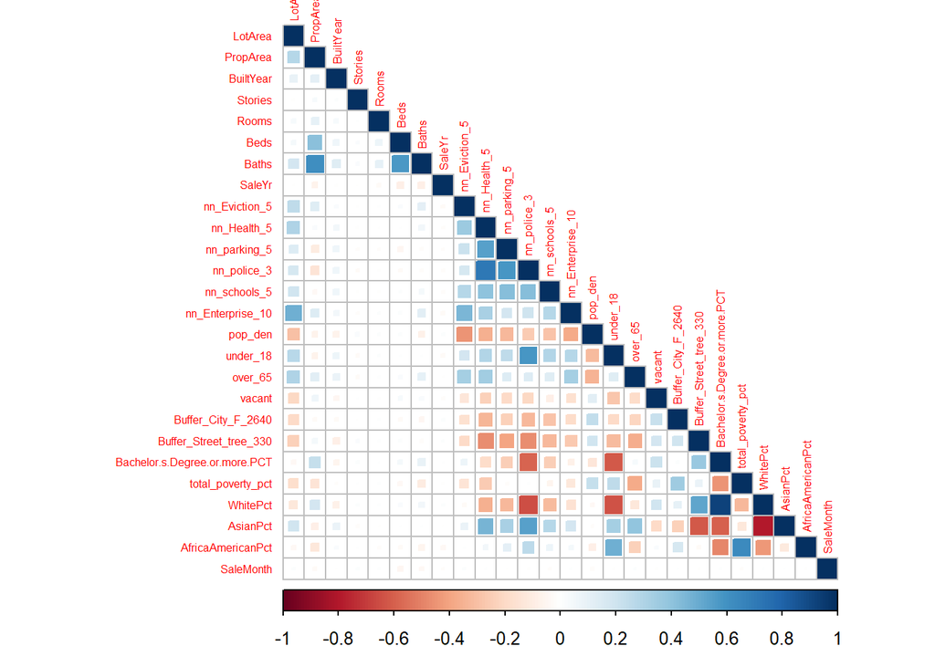

```r
SFCor <-
  d_3 %>%
  st_set_geometry(NULL) %>%
  dplyr::select(LotArea, PropArea, BuiltYear, Stories, Rooms,
                Beds, Baths, SaleYr,
                nn_Eviction_5, nn_Health_5,
                nn_parking_5, nn_police_3,
                nn_schools_5,
                nn_Enterprise_10,
                pop_den, under_18, over_65, vacant,
                Buffer_City_F_2640, Buffer_Street_tree_330,
                Bachelor.s.Degree.or.more.PCT, total_poverty_pct, WhitePct,
                AsianPct, AfricaAmericanPct, SaleMonth)

M <- cor(SFCor,use="pairwise.complete.obs")
corrplot(M, method = "square",type = "lower",tl.cex = 0.5)
```

## Scatterplots of Four Interesting Predictors and Sale Price

The following presents four interesting scatterplots between predictors and dependent variable: city facilities within 1/2 miles buffer, average distance to 5 nearest health centers, average distance to 3 nearest police station, and average distance to 5 nearest schools. City facilities varies in different types, such as parks and public squares, which are the cores of a city. The number of facilities that can be reached within 1/2miles buffer of the house, representing the convenience of the house to the public centers of the city. Health centers are the guarantees of people’s healthy life. People are increasingly aware that it is important to have a house near the health centers. In the scatterplot on the upper right, we can see that house prices are gradually decreasing as the average distance from the health centers increases. The police stations and schools have the same principle: people are eager to get close to the police station to protect their safety, and nearer schools provides convenience for kids attending schools. Thus, for the below scatterplots, both of their house price deceasing when the distances to police stations and schools increasing.

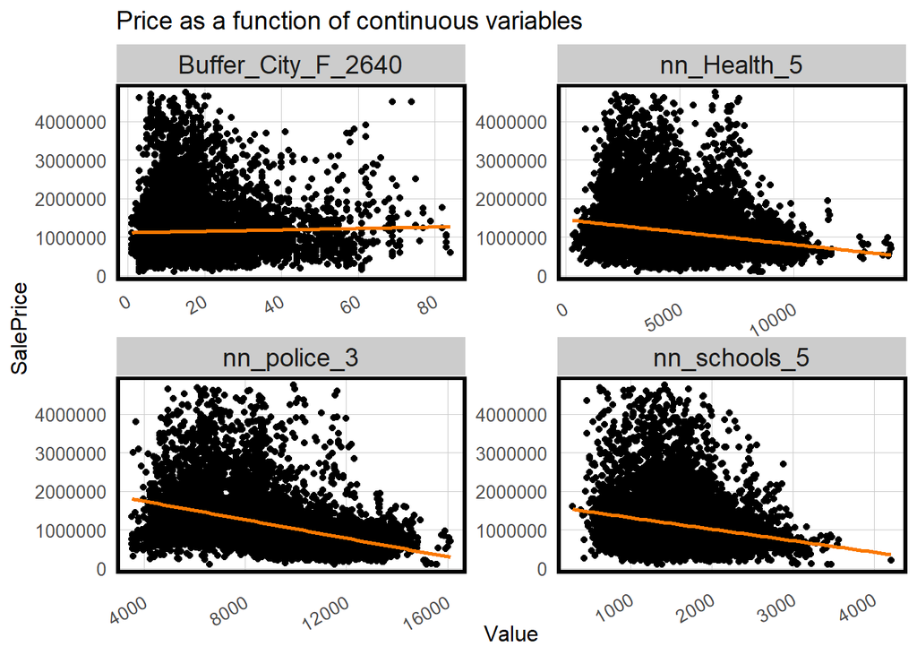

```r
as.data.frame(d_3[which(d_3$holdOut == 0),]) %>%
  dplyr::select(SalePrice, Buffer_City_F_2640, nn_police_3, nn_Health_5, nn_schools_5)%>%
  gather(Variable, Value, -SalePrice) %>%
   ggplot(aes(Value,SalePrice)) +
     geom_point() +
     geom_smooth(method = "lm", se=F, colour = "#FA7800") +
     facet_wrap(~Variable, ncol = 2,nrow = 2, scales = "free") +
     labs(title = "Price as a function of continuous variables") +
     theme(axis.text.x = element_blank()) +
     theme(axis.text.x = element_text(angle = 30, hjust = 1)) +
     plotTheme()
```

## Sale Price Map

This map shows clear trends and trends from a visual perspective. Intuitively, because the downtown of San Francisco is in the upper right corner of the city, we can see that the high prices are basically concentrated in the middle and northeast, where is closer to the city center.

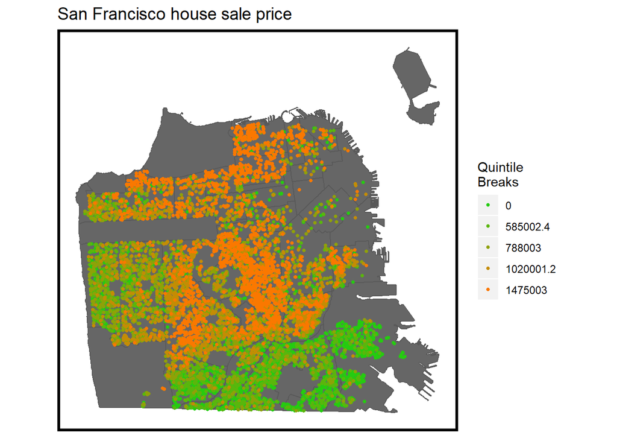

```r
#======== pridiction of entire dataset ==========
ggplot() +
  geom_sf(data = Neighbor, fill = "grey40") +
  geom_sf(data = d_3[which(d_3$holdOut == 0),], aes(colour = q5(SalePrice)), show.legend = "point", size = 1) +
  scale_colour_manual(values = palette5,
                      labels=qBr(d_3,"SalePrice"),
                      name="Quintile\nBreaks") +
  labs(title="San Francisco house sale price") +
  mapTheme()
```

## Maps of Three Interesting Independent Variables

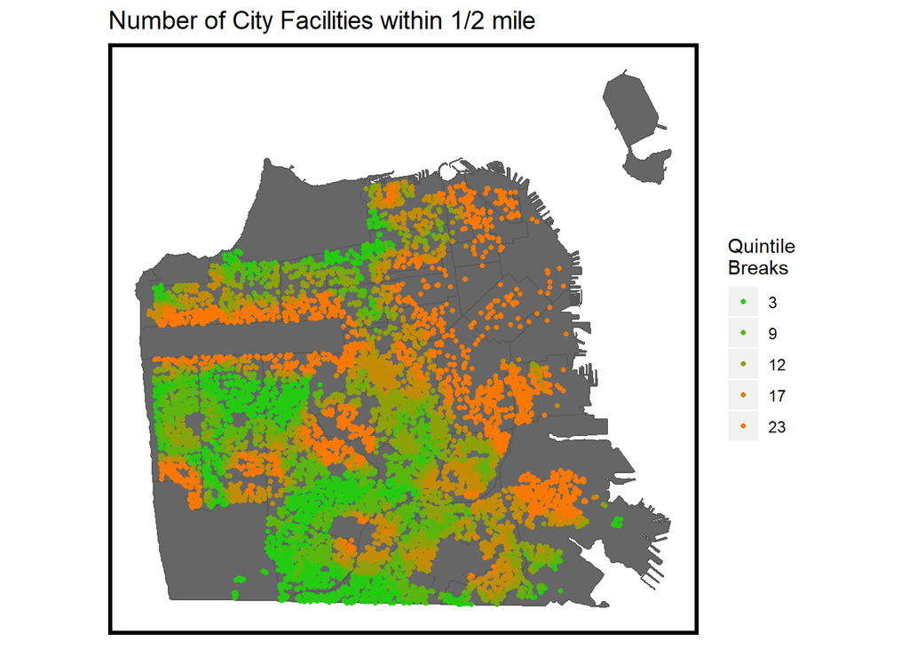

```r
ggplot() +
  geom_sf(data = Neighbor, fill = "grey40") +
  geom_sf(data = d_3, aes(colour = q5(Buffer_City_F_2640)), show.legend = "point", size = 1) +
  scale_colour_manual(values = palette5,
                      labels=qBr(d_3,"Buffer_City_F_2640"),
                      name="Quintile\nBreaks") +
  labs(title="Number of City Facilities within 1/2 mile") +
  mapTheme()
```

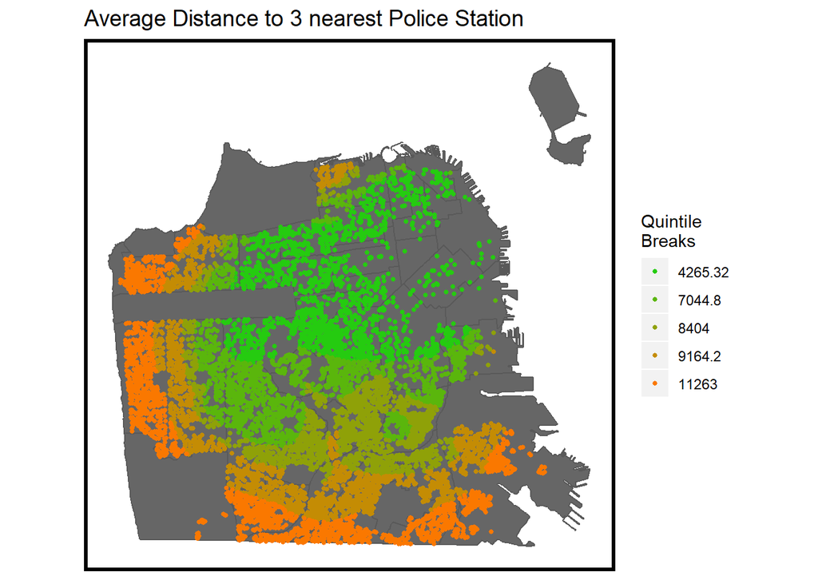

```r
ggplot() +
  geom_sf(data = Neighbor, fill = "grey40") +
  geom_sf(data = d_3, aes(colour = q5(nn_police_3)), show.legend = "point", size = 1) +
  scale_colour_manual(values = palette5,
                      labels=qBr(d_3,"nn_police_3"),
                      name="Quintile\nBreaks") +
  labs(title="Average Distance to 3 nearest Police Station") +
  mapTheme()
```

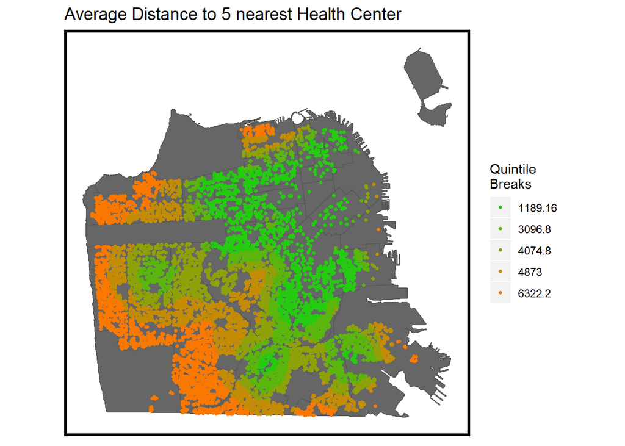

```r
ggplot() +
  geom_sf(data = Neighbor, fill = "grey40") +
  geom_sf(data = d_3, aes(colour = q5(nn_Health_5)), show.legend = "point", size = 1) +
  scale_colour_manual(values = palette5,
                      labels=qBr(d_3,"nn_Health_5"),
                      name="Quintile\nBreaks") +
  labs(title="Average Distance to 5 nearest Health Center") +
  mapTheme()
```

## Some Interesting Correlations

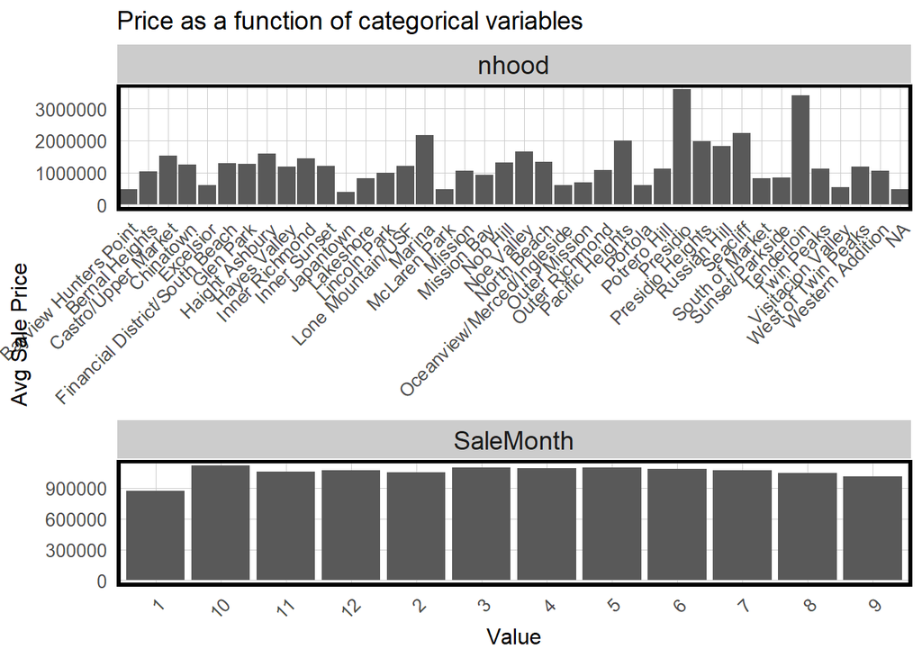

```r
d_3_2 <- d_3 %>%
  dplyr::select(SalePrice, nhood, SaleMonth)

d_3_2 %>%
  as.data.frame() %>%
  dplyr::select(-geometry) %>%
  gather(Variable, Value, -SalePrice) %>%
   ggplot(aes(x = Value,
              y = SalePrice)) +
     geom_bar(stat = "summary", fun.y = "mean", position = "dodge") +
     facet_wrap(~Variable, ncol = 1, scales = "free") +
     labs(title = "Price as a function of categorical variables",
          y = "Avg Sale Price") +
     theme(axis.text.x = element_text(angle = 45, hjust = 1)) +
     plotTheme() + scale_y_continuous()
```

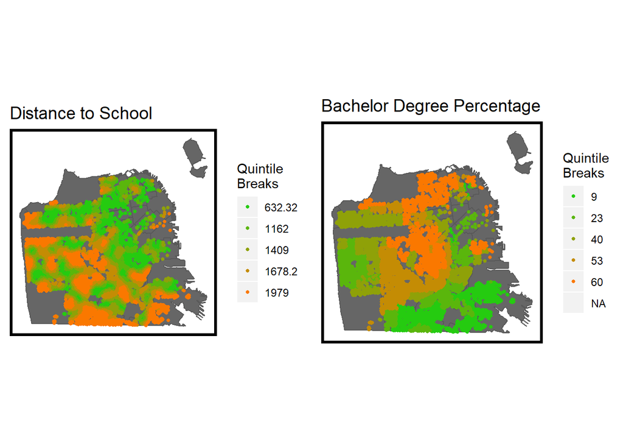

```r
grid.arrange(
  ggplot() +
      geom_sf(data = Neighbor, fill = "grey40") +
      geom_sf(data = d_3, aes(colour = q5(nn_schools_5)), show.legend = "point", size = 1) +
      scale_colour_manual(values = palette5,
                       labels = qBr(d_3, "nn_schools_5"),
                       name = "Quintile\nBreaks") +
      labs(title = "Distance to School") +
      mapTheme(),

  ggplot() +
      geom_sf(data = Neighbor, fill = "grey40") +
      geom_sf(data = d_3, aes(colour = q5(Bachelor.s.Degree.or.more.PCT)), show.legend = "point", size = 1) +
      scale_colour_manual(values = palette5,
                       labels = qBr(d_3, "Bachelor.s.Degree.or.more.PCT"),
                       name = "Quintile\nBreaks") +
      labs(title = "Bachelor Degree Percentage") +
      mapTheme(),
ncol = 2)
```

# 3.Methods

## 3.1 Data Wrangling

Data wrangling is the first step to clean all the data. All the data are set to same coordinate system and same format. One quarter of original data is separated as testing data and three quarters data serve as the training data. The NAs of numerical data are set as the average of other observations, and NAs of categorical data are set to unknown. The data wrangling helps us deal with the data with missing data and increase the prediction accuracy.

## 3.2 Feature Engineering

Different types of data are processed in different ways based on their characteristics for the model input. N nearest distance, buffer, and spatial join are used to generate the appropriate predictors in model. Some numerical variables are transformed into dummy variables to give more precise illustrations. The feature engineering helps use the raw data from open data source.

## 3.3 Model Feature Selection

There are four versions of models trained by us for selecting appropriate variables. We use k-fold cross-validation to test the consistency of the model. The k-fold cross-validation divides the training set into equal parts and uses them as test sets. We also use stepwise regression as a reference for choosing the right parameters, which allows our model to cover more valuable predictors. With the model feature collection, the data are more readable, and the model can fit better.

## 3.4 Spatial Structure Analysis

After obtaining the final model, Moran’s I was calculated to evaluate the spatial autocorrelation of the residuals, and the race and income dichotomization data were used to evaluate the model’s generalizability. The Zillow manager can visually observe the spatial autocorrelation results of model through Moran’s I and assess generalizability based on the table of different context data.

# 4.Results

## Training Set Result

```r
set.seed(113219718)
d_2 = d_3[ which(d_3$holdOut == 0),]
smp_size <- floor(0.75 * nrow(d_2))
train_ind <- sample(seq_len(nrow(d_2)),size = smp_size)
d_2.train <- d_2[train_ind, ]
d_2.test <- d_2[-train_ind, ]
regression <- lm(SalePrice ~ ., data = as.data.frame(d_2.train) %>%
             dplyr::select(SalePrice,
                           LotArea, PropArea, BuiltYear.cat, Stories.cat, Rooms.cat,
                           Beds.cat, Baths.cat, SaleYr, district_N.cat,
                           nn_Eviction_5, nn_Health_5, nn_meter_motor_50,
                           nn_parking_5, nn_police_3, nn_restaurant_50.cat,
                           nn_schools_5,  nn_Traffic_Calming_Point_Features_25,
                           nn_Enterprise_10,
                           pop_den, under_18, over_65, vacant,
                           Buffer_City_F_2640,
                           Bachelor.s.Degree.or.more.PCT, total_poverty_pct, WhitePct,
                           AsianPct, AfricaAmericanPct, SaleMonth, PropClassC, ZoningCode_N.cat,
                           ConstType_N.cat
             ))
require(broom)
tidy(regression)%>% kable() %>% kable_styling("striped", full_width = F)
```

| term | estimate | std.error | statistic | p.value |
| --- | --- | --- | --- | --- |
| (Intercept) | -4629779.8532687 | 318134.8443205 | -14.5528852 | 0.0000000 |
| LotArea | 0.3699893 | 0.0485546 | 7.6200656 | 0.0000000 |
| PropArea | 408.1637792 | 10.1393967 | 40.2552334 | 0.0000000 |
| BuiltYear.cat1960 to 2009 | -69770.5099048 | 15631.4195529 | -4.4634788 | 0.0000082 |
| BuiltYear.cat2010+ | 60139.1219989 | 43517.1676663 | 1.3819631 | 0.1670271 |
| BuiltYear.catless than 1870 | 458925.6128736 | 48609.8871829 | 9.4409932 | 0.0000000 |
| Stories.cat5+ Floors | -352384.8016275 | 167242.6240730 | -2.1070275 | 0.0351506 |
| Stories.catUp to 2 Floors | -166135.3273015 | 22392.2780410 | -7.4193133 | 0.0000000 |
| Rooms.cat8 to 13 rooms | 481850.1423224 | 73157.2777508 | 6.5864963 | 0.0000000 |
| Rooms.catUp to 7 rooms | 500062.4246821 | 74815.9943347 | 6.6838973 | 0.0000000 |
| Beds.cat7+ beds | -240604.5910645 | 86186.9436014 | -2.7916594 | 0.0052581 |
| Beds.catUp to 4 beds | 112281.5955251 | 24516.8171853 | 4.5797786 | 0.0000047 |
| Baths.cat6+ baths | -262528.2670109 | 85271.8231186 | -3.0787223 | 0.0020869 |
| Baths.catUp to 2 baths | -74262.1666236 | 14463.5910943 | -5.1344211 | 0.0000003 |
| SaleYr | 169104.0276283 | 3989.0223976 | 42.3923485 | 0.0000000 |
| district_N.catCENTRAL | 198865.4034472 | 64024.4225536 | 3.1060866 | 0.0019034 |
| district_N.catINGLESIDE | -27647.3245034 | 23711.6348387 | -1.1659814 | 0.2436617 |
| district_N.catMISSION | 53575.5035290 | 32314.8896897 | 1.6579200 | 0.0973784 |
| district_N.catNORTHERN | 242525.8018650 | 43473.8558654 | 5.5786586 | 0.0000000 |
| district_N.catPARK | -31686.3477281 | 31435.3701855 | -1.0079839 | 0.3134970 |
| district_N.catRICHMOND | 131479.9488860 | 30928.2345960 | 4.2511301 | 0.0000215 |
| district_N.catTARAVAL | -42574.3625677 | 26144.6108312 | -1.6284183 | 0.1034812 |
| district_N.catNone | 197082.7654654 | 64866.9758697 | 3.0382604 | 0.0023882 |
| nn_Eviction_5 | 180.4230530 | 40.2928063 | 4.4777981 | 0.0000077 |
| nn_Health_5 | -57.6691045 | 5.0366816 | -11.4498214 | 0.0000000 |
| nn_meter_motor_50 | -78.2396911 | 4.7906179 | -16.3318581 | 0.0000000 |
| nn_parking_5 | 18.8122840 | 5.9381256 | 3.1680509 | 0.0015412 |
| nn_police_3 | 68.7862546 | 6.6836781 | 10.2916768 | 0.0000000 |
| nn_restaurant_50.cat2000+ to restaurants | -51780.8808779 | 19255.6604830 | -2.6891251 | 0.0071809 |
| nn_restaurant_50.cat600~1200 to restaurants | -5730.4060566 | 11349.8976752 | -0.5048861 | 0.6136547 |
| nn_restaurant_50.catrestaurants in 600 | -25637.7320367 | 16280.3148428 | -1.5747688 | 0.1153550 |
| nn_schools_5 | -34.3555605 | 12.2922408 | -2.7948981 | 0.0052057 |
| nn_Traffic_Calming_Point_Features_25 | 45.8933607 | 6.0800876 | 7.5481414 | 0.0000000 |
| nn_Enterprise_10 | 927.4796660 | 333.8140910 | 2.7784317 | 0.0054767 |
| pop_den | 4.2730687 | 0.8763264 | 4.8761154 | 0.0000011 |
| under_18 | 1753739.3968993 | 220067.9892032 | 7.9690799 | 0.0000000 |
| over_65 | -436613.9790767 | 160918.2298722 | -2.7132661 | 0.0066786 |
| vacant | 1188329.2231780 | 206499.5935554 | 5.7546323 | 0.0000000 |
| Buffer_City_F_2640 | -3567.0761711 | 507.4320113 | -7.0296633 | 0.0000000 |
| Bachelor.s.Degree.or.more.PCT | 6078.1924794 | 1053.3026043 | 5.7706042 | 0.0000000 |
| total_poverty_pct | -268543.0418249 | 160123.7698866 | -1.6770967 | 0.0935682 |
| WhitePct | 11530.4914656 | 1878.3140797 | 6.1387452 | 0.0000000 |
| AsianPct | 4824.6015050 | 1483.7263534 | 3.2516788 | 0.0011527 |
| AfricaAmericanPct | 8569.6890311 | 1748.9383052 | 4.8999379 | 0.0000010 |
| SaleMonth | 9065.6067506 | 1348.6634382 | 6.7219193 | 0.0000000 |
| PropClassCD | 1122897.4847739 | 261070.3636326 | 4.3011297 | 0.0000172 |
| PropClassCDA | 1195797.9444605 | 283592.9729438 | 4.2165993 | 0.0000251 |
| PropClassCF | 1033570.6003215 | 267934.7462405 | 3.8575460 | 0.0001156 |
| PropClassCLZ | 791905.6662429 | 277308.9285476 | 2.8556804 | 0.0043071 |
| PropClassCOZ | 39247.0453167 | 460143.7460919 | 0.0852930 | 0.9320309 |
| PropClassCTH | 807415.4626432 | 284646.3165165 | 2.8365569 | 0.0045734 |
| PropClassCTIC | -125032.7602983 | 270342.3505554 | -0.4624979 | 0.6437387 |
| PropClassCZ | 749190.4958208 | 261991.9160558 | 2.8595939 | 0.0042544 |
| PropClassCZBM | 419592.2362048 | 297316.0848226 | 1.4112665 | 0.1582104 |
| PropClassCZEU | 4181229.7860750 | 455467.2380961 | 9.1800890 | 0.0000000 |
| ZoningCode_N.catRH1D | 8186.7170287 | 20530.0968116 | 0.3987666 | 0.6900773 |
| ZoningCode_N.catRH2 | -67510.9722972 | 14758.1536748 | -4.5744863 | 0.0000049 |
| ZoningCode_N.catRH3 | -96883.7364127 | 27611.8690921 | -3.5087714 | 0.0004530 |
| ZoningCode_N.catRM1 | -60982.2210048 | 32829.2296503 | -1.8575587 | 0.0632736 |
| ZoningCode_N.catNone | -72188.9798944 | 27199.0959651 | -2.6540948 | 0.0079701 |
| ConstType_N.catWOO | -65347.9017136 | 50977.2922846 | -1.2819022 | 0.1999194 |
| ConstType_N.catNone | 40607.6701018 | 23606.1838158 | 1.7202132 | 0.0854378 |

```r
training.result <- matrix(c(summary(regression)$r.squared,summary(regression)$adj.r.squared),ncol=2,byrow=TRUE)
colnames(training.result) <- c("R square","Adjusted R square")
rownames(training.result) <- c("Training set")
training.result <- as.table(training.result)
training.result %>% kable() %>% kable_styling("striped", full_width = F)
```

|  | R square | Adjusted R square |
| --- | --- | --- |
| Training set | 0.7350215 | 0.7327151 |

## Test Set Result

```r
d_2.test<-
  d_2.test %>%
  mutate(SalePrice.Predict = predict(regression, d_2.test),
         SalePrice.Error = SalePrice - SalePrice.Predict,
         SalePrice.AbsError = abs(SalePrice - SalePrice.Predict),
         SalePrice.APE = (abs(SalePrice - SalePrice.Predict)) / SalePrice)
```

```r
#======== R square ==========
test.rsq <- cor(d_2.test$SalePrice, d_2.test$SalePrice.Predict, method = "pearson",use = "complete.obs") ^ 2
#======== MAE ==========
test.mae <- mean(d_2.test$SalePrice.AbsError, na.rm = T)

#======== MAPE ==========
test.mape <- mean(d_2.test$SalePrice.APE, na.rm = T)

#======== test.result table ==========
test.result <- matrix(c(test.rsq,test.mae,test.mape),ncol=3,byrow=TRUE)
colnames(test.result) <- c("R square","MAE","MAPE")
rownames(test.result) <- c("Test set")
test.result <- as.table(test.result)
test.result %>% kable() %>% kable_styling("striped", full_width = F)
```

|  | R square | MAE | MAPE |
| --- | --- | --- | --- |
| Test set | 0.6166984 | 253871.2 | 0.2642415 |

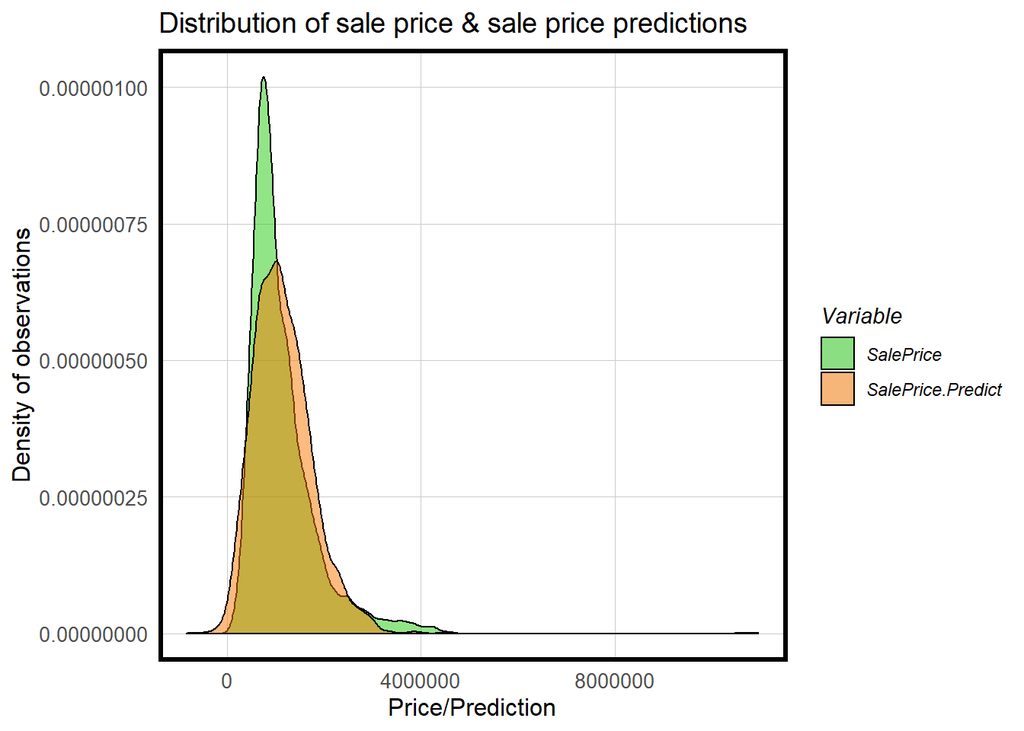

```r
#======== Graph ==========
as.data.frame(d_2.test) %>%
  dplyr::select(SalePrice, SalePrice.Predict) %>%
  gather(Variable, Value) %>%
  ggplot(aes(Value, fill = Variable)) +
  geom_density(alpha = 0.5) +
  scale_fill_manual(values = c("#25CB10", "#FA7800")) +
  labs(title="Distribution of sale price & sale price predictions",
       x = "Price/Prediction", y = "Density of observations") +
  plotTheme()
```

## Cross Validation

```r
#======== CV ==========
fitControl <- trainControl(method = "cv", number = 100)
set.seed(825)
regression.cv <- train(SalePrice ~ ., data = as.data.frame(d_2) %>%
                   dplyr::select(SalePrice,
                                 LotArea, PropArea, BuiltYear.cat, Stories.cat, Rooms.cat,
                                 Beds.cat, Baths.cat, SaleYr, district_N.cat,
                                 nn_Eviction_5, nn_Health_5, nn_meter_motor_50,
                                 nn_parking_5, nn_police_3, nn_restaurant_50.cat,
                                 nn_schools_5,  nn_Traffic_Calming_Point_Features_25,
                                 nn_Enterprise_10,
                                 pop_den, under_18, over_65, vacant,
                                 Buffer_City_F_2640,
                                 Bachelor.s.Degree.or.more.PCT, total_poverty_pct, WhitePct,
                                 AsianPct, AfricaAmericanPct, SaleMonth, PropClassC, ZoningCode_N.cat,
                                 ConstType_N.cat),
                 method = "lm", trControl = fitControl, na.action = na.pass)

regression.cv
```

```
## Linear Regression
##
## 9433 samples
##   32 predictor
##
## No pre-processing
## Resampling: Cross-Validated (100 fold)
## Summary of sample sizes: 9341, 9339, 9339, 9339, 9339, 9339, ...
## Resampling results:
##
##   RMSE      Rsquared   MAE
##   376352.1  0.7188327  256093.2
##
## Tuning parameter 'intercept' was held constant at a value of TRUE
```

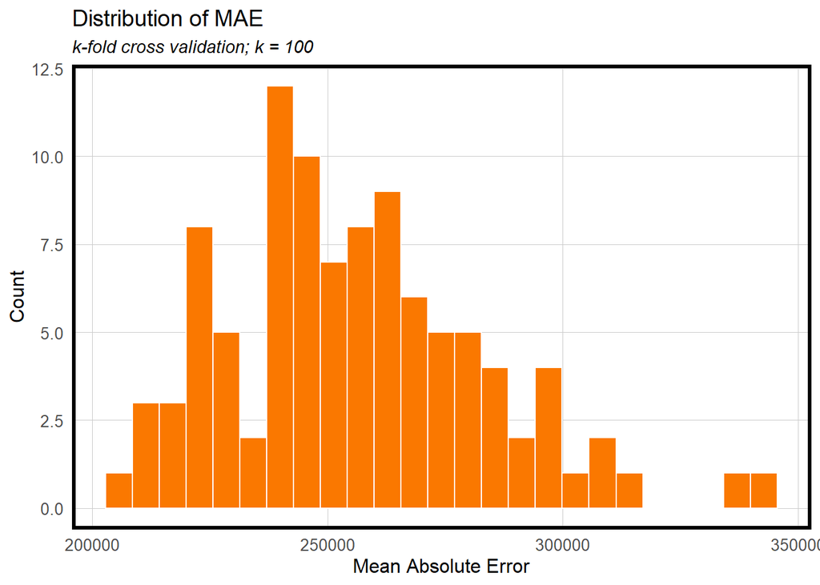

```r
ggplot(as.data.frame(regression.cv$resample), aes(MAE)) +
  geom_histogram(bins = 25, colour="white", fill = "#FA7800") +
  labs(title="Distribution of MAE", subtitle = "k-fold cross validation; k = 100",
       x="Mean Absolute Error", y="Count") +
  plotTheme()
```

Based on the result of cross validation, whose MAE is near our regression MAE, I think our model is not overfit.

## Predicted prices as a function of observed prices

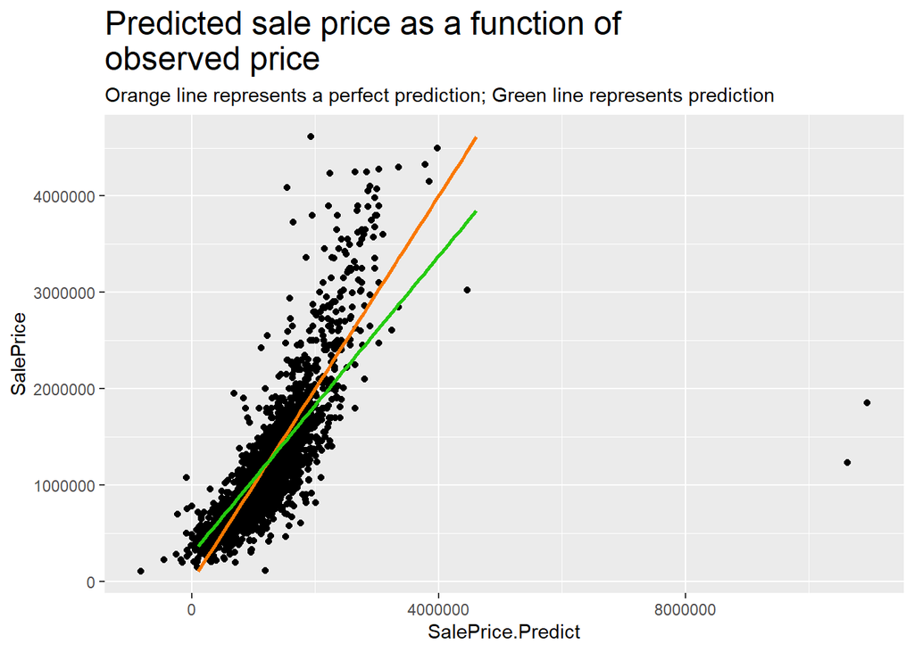

```r
ggplot(d_2.test, aes(SalePrice.Predict, SalePrice)) +
  geom_point() +
  stat_smooth(data=d_2.test, aes(SalePrice, SalePrice),
              method = "lm", se = FALSE, size = 1, colour="#FA7800") +
  stat_smooth(data=d_2.test, aes(SalePrice, SalePrice.Predict),
              method = "lm", se = FALSE, size = 1, colour="#25CB10") +
  labs(title="Predicted sale price as a function of\nobserved price",
       subtitle="Orange line represents a perfect prediction; Green line represents prediction") +
  theme(plot.title = element_text(size = 18,colour = "black"))
```

## Test set residuals

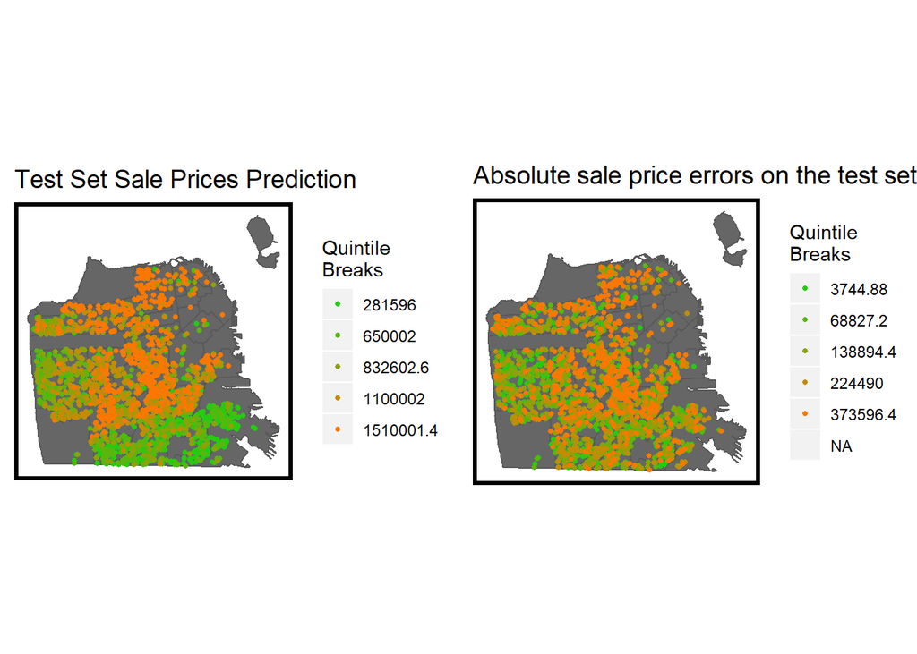

```r
grid.arrange(
  ggplot() +
    geom_sf(data = Neighbor, fill = "grey40") +
    geom_sf(data = d_2.test, aes(colour = q5(SalePrice)), show.legend = "point", size = 1) +
    scale_colour_manual(values = palette5,
                        labels=qBr(d_2.test,"SalePrice"),
                        name="Quintile\nBreaks") +
    labs(title="Test Set Sale Prices Prediction") +
    mapTheme(),

  ggplot() +
    geom_sf(data = Neighbor, fill = "grey40") +
    geom_sf(data = d_2.test, aes(colour = q5(SalePrice.AbsError)), show.legend = "point", size = 1) +
    scale_colour_manual(values = palette5,
                        labels=qBr(d_2.test,"SalePrice.AbsError"),
                        name="Quintile\nBreaks") +
    labs(title="Absolute sale price errors on the test set") +
    mapTheme(),
  ncol = 2)
```

## Moran’s I test

[figure not shown]

```r
d_2.test_predict <- d_2.test[which(d_2.test$SalePrice.Error != 0),]
coords.test <- d_2.test_predict %>%
  st_coordinates()

neighborList.test <- knn2nb(knearneigh(coords.test, 5))

spatialWeights.test <- nb2listw(neighborList.test, style="W")

d_2.test_predict$lagPriceError <- lag.listw(spatialWeights.test, d_2.test_predict$SalePrice.Error)

moranTest <- moran.mc(d_2.test_predict$SalePrice.Error,
                      spatialWeights.test , nsim = 999)

ggplot(as.data.frame(moranTest$res[c(1:999)]), aes(moranTest$res[c(1:999)])) +
  geom_histogram(binwidth = 0.01) +
  geom_vline(aes(xintercept = moranTest$statistic), colour = "#FA7800",size=1) +
  scale_x_continuous(limits = c(-1, 1)) +
  labs(title="Observed and permuted Moran's I",
       subtitle= "Observed Moran's I for Prediction Errors (statistic = 0.041, p-value = 0.001) in red",
       x="Moran's I",
       y="Count") +
  plotTheme()
```

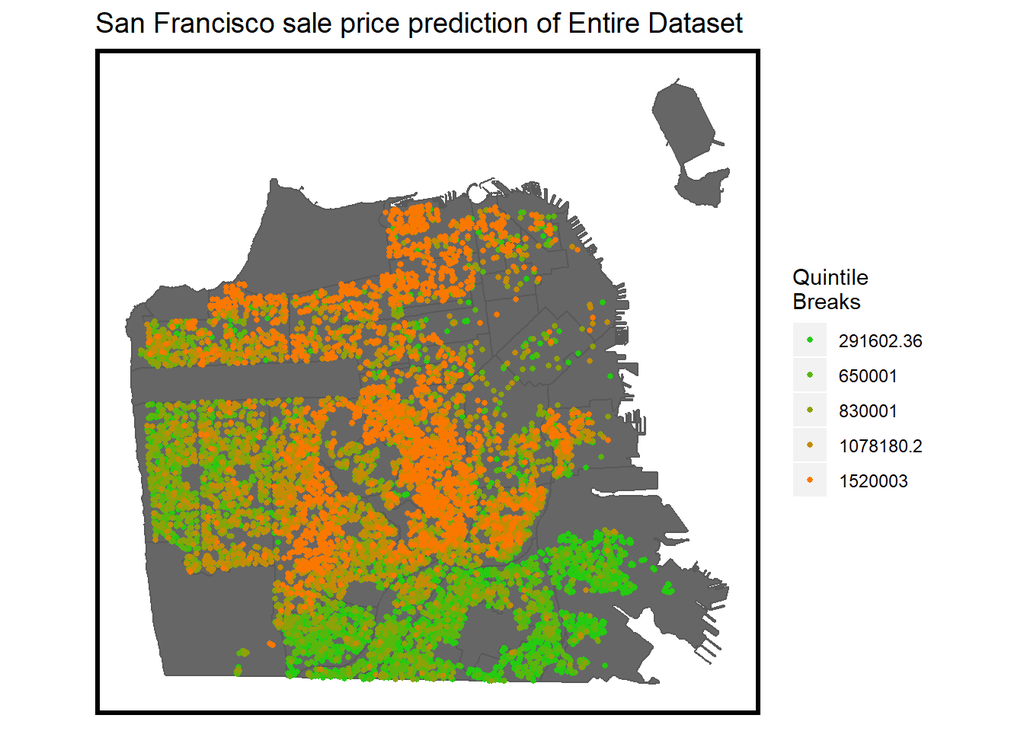

```r
#======== pridiction of entire dataset ==========
ggplot() +
  geom_sf(data = Neighbor, fill = "grey40") +
  geom_sf(data = d_2, aes(colour = q5(SalePrice)), show.legend = "point", size = 1) +
  scale_colour_manual(values = palette5,
                      labels=qBr(d_2,"SalePrice"),
                      name="Quintile\nBreaks") +
  labs(title="San Francisco sale price prediction of Entire Dataset") +
  mapTheme()
```

## MAPE by Neighborhood

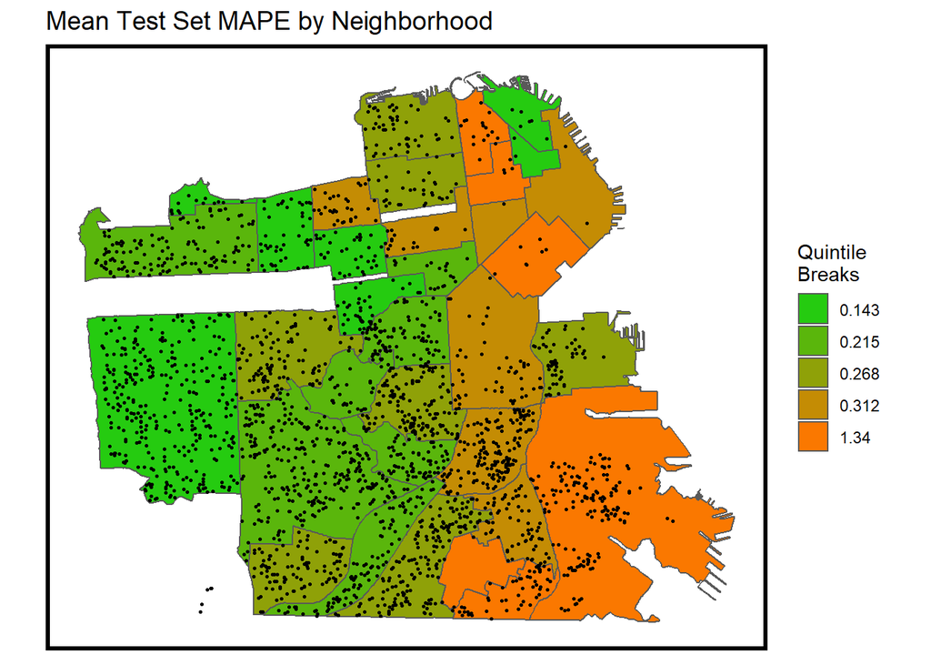

```r
#======== mean MAPE by neighborhood map ==========
d_2_MAPE.nhood <-
  d_2.test[which(d_2.test$nhood != 0),] %>%
  group_by(nhood) %>%
  summarize(mean.MAPE = mean(SalePrice.APE, na.rm = T)) %>%
  st_set_geometry(NULL) %>%
  left_join(Neighbor,by = 'nhood') %>%
  st_sf()
d_2_MAPE.nhood<-d_2_MAPE.nhood[!(d_2_MAPE.nhood$nhood=="Lakeshore"),]
ggplot() +
  geom_sf(data = d_2_MAPE.nhood, aes(fill = q5(mean.MAPE))) +
  geom_sf(data = d_2.test, colour = "black", size = .5) +
  scale_fill_manual(values = palette5,
                    labels = qBr(d_2_MAPE.nhood, "mean.MAPE", rnd = F),
                    name="Quintile\nBreaks") +
  labs(title = "Mean Test Set MAPE by Neighborhood") +
  mapTheme()
```

## Scatterplot plot of MAPE as a function of mean price by neighborhood

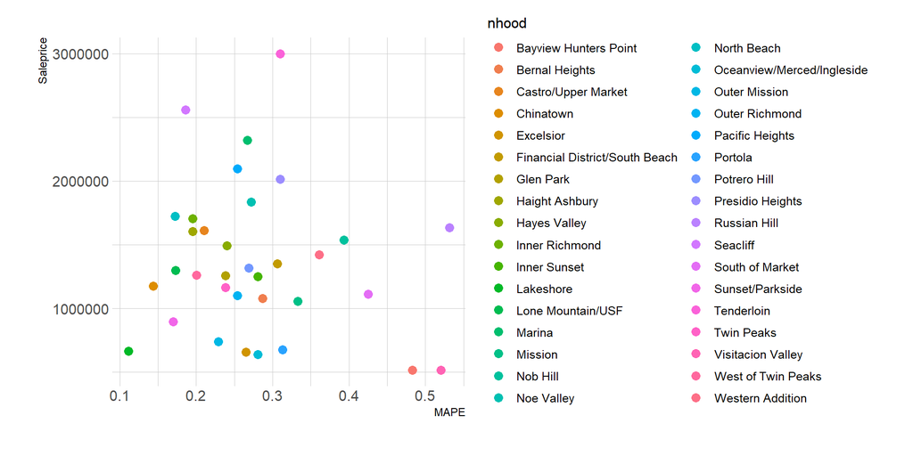

```r
#======== Prediction mean by neighborhood==========
d_2_MAPE <-
  st_set_geometry(d_2.test_predict[which(d_2.test_predict$nhood != 0),], NULL) %>%
    group_by(nhood) %>%
    summarize(MAPE = mean(SalePrice.APE, na.rm = T))
d_2_Saleprice <-
  st_set_geometry(d_2.test_predict[which(d_2.test_predict$nhood != 0),], NULL) %>%
    group_by(nhood) %>%
    summarize(Saleprice = mean(SalePrice, na.rm = T))

d_2_MAPE_Salesprice <- merge(d_2_MAPE,d_2_Saleprice)

library(ggplot2)

library(hrbrthemes)
ggplot(d_2_MAPE_Salesprice[which(d_2_MAPE_Salesprice$MAPE<1),], aes(x=MAPE, y=Saleprice, color=nhood)) +
    geom_point(size=3) +
    theme_ipsum()
```

## Model’s generalizability

```r
#======== context map ==========
tracts_1 <- tracts[ which(tracts$geoid10 !="06075980401"),]
#772465bff3e908b0e7f1bdad945c1562bb0042b6
#census_api_key("772465bff3e908b0e7f1bdad945c1562bb0042b6", overwrite = FALSE,install = TRUE)



tracts_17 <-
  get_acs(geography = "tract", variables = c("B01001_001E","B01001A_001E","B06011_001"),
          year = 2017, state=06, county=075, geometry=T) %>%
  st_transform(2227)  %>%
  dplyr::select(variable, estimate, GEOID) %>%
  spread(variable, estimate) %>%
  rename(TotalPop = B01001_001,
         NumberWhites = B01001A_001,
         Median_Income = B06011_001) %>%
  mutate(percentWhite = NumberWhites / TotalPop,
         raceContext = ifelse(percentWhite > .5, "Majority White", "Majority Non-White"),
         incomeContext = ifelse(Median_Income > 32322, "High Income", "Low Income"))
```

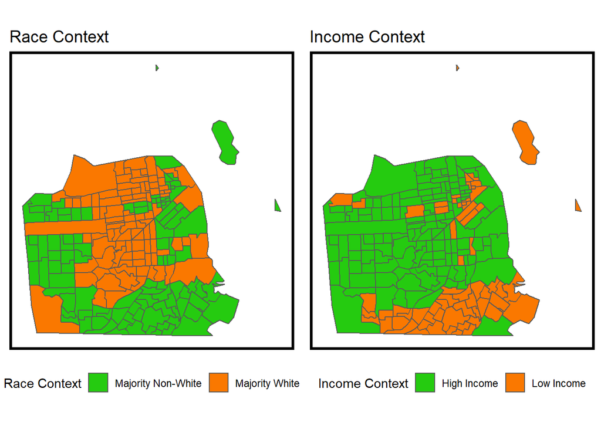

```r
grid.arrange(
  ggplot() +
    geom_sf(data = na.omit(tracts_17), aes(fill = raceContext)) +
    scale_fill_manual(values = c("#25CB10", "#FA7800"),
                      name="Race Context") +
    labs(title = "Race Context") +
    mapTheme() + theme(legend.position="bottom"),

  ggplot() +
    geom_sf(data = na.omit(tracts_17), aes(fill = incomeContext)) +
    scale_fill_manual(values = c("#25CB10", "#FA7800"),
                      name="Income Context") +
    labs(title = "Income Context") +
    mapTheme() + theme(legend.position="bottom"), ncol = 2)
```

```r
d_2.test_predict <-
  d_2.test_predict %>%
  st_join(dplyr::select(tracts_17, raceContext))

d_2.test_predict <-
  d_2.test_predict %>%
  st_join(dplyr::select(tracts_17, incomeContext))

d_2_raceContext <-
  st_set_geometry(d_2.test_predict[which(d_2.test_predict$raceContext != 0),], NULL) %>%
    group_by(raceContext) %>%
    summarize(MAPE = mean(SalePrice.APE, na.rm = T),MAE = mean(SalePrice.AbsError, na.rm = T)) %>%
    rename(Context = raceContext)
d_2_incomeContext <-
  st_set_geometry(d_2.test_predict[which(d_2.test_predict$incomeContext != 0),], NULL) %>%
    group_by(incomeContext) %>%
    summarize(MAPE = mean(SalePrice.APE, na.rm = T),MAE = mean(SalePrice.AbsError, na.rm = T))%>%
    rename(Context = incomeContext)
rbind(d_2_raceContext, d_2_incomeContext) %>%
    kable(caption = "") %>%
    kable_styling("striped", full_width = F, position = "left") %>%
    row_spec(1, color = "black", background = "#25CB10") %>%
    row_spec(2, color = "black", background = "#25CB10") %>%
    row_spec(3, color = "black", background = "#FA7800") %>%
    row_spec(4, color = "black", background = "#FA7800")
```

| Context | MAPE | MAE |
| --- | --- | --- |
| Majority Non-White | 0.2827095 | 198877.6 |
| Majority White | 0.2397208 | 326888.3 |
| High Income | 0.2305232 | 275921.7 |
| Low Income | 0.3547541 | 194679.3 |

To a certain extent, our model is generalizable. Because it can performs some similarity in different contexts. Looking at the MAE, it represents that our modelcan estimate low-income areas more accurately, and less effective in high-income areas. However, looking ata the MAPE, things have completely reversed. The model change to be more effective in high-income areas and majority-white area. The same thing happens in the racial context. MAE and MAPE showded some kind of complementarity, MAE is higher in majority-white area and MAPE is higher in majority non-white area. Although there are differences in each coefficient under different contexts, the average prediction accuracy of the model is similar to the overall average accuracy when we taking both MAE and MAPE into consideration, so the model has a certain generalizability.

# 5. Discussion

From the overall results, our model is effective in predicting the function of housing prices. Our R square is about 0.74, which means we can explain 73.50% house prices. In general, our model can be used as a reference for Zillow, but not as a decisive factor.

# 6. Conclusion

Based on our study results, we would recommend our model to Zillow, but I will definitely add important hints - our findings can only be used as a secondary reference and not as a key determinant because of its poor accuracy. In addition, there is spatial autocorrelation that has not been solved in it. We have several aspects to be improved in the future Zillow’s use:

- Apply spatial lag to quantify the spatial autocorrelation rather than leave it in residual.
- Use more advanced feature engineering to transform variables, such as log or power functions, to make them perform better in the OLS model.
- Improve the accuracy of existing data and discover more versions of the same period, rather than current data which varies over a decade.
- Increase some undiscovered indicators into the model, especially those help predict high housing price areas
- Try other types regression rather than OLS to reduce the error caused by nonlinear variables.

In this way, our model can provide Zillow with a better prediction of house sales price in the future.

# 7. References

Alfiyatin, A. N., Febrita, R. E., Taufiq, H., & Mahmudy, W. F. (2017). Modeling House Price Prediction using Regression Analysis and Particle Swarm Optimization. International Journal of Advanced Computer Science and Applications.

Chen, X., Wei, L., & Xu, J. (2017). House Price Prediction Using LSTM. arXiv preprint arXiv:1709.08432.